# R Notebook

Week 11 Day 2 Homework

Decision Trees

In this homework we will create a decision tree to see which factors are useful in predicting whether or not a passenger on the titanic will survive.

Run the code below before you begin:

```r
library(rpart)
library(rpart.plot)
library(tidyverse)
library(janitor)

titanic_set <- read_csv('data/titanic_decision_tree_data.csv')
```

```
* `` -> ...1
```

```r
shuffle_index <- sample(1:nrow(titanic_set))

# shuffle the data so class order isn't in order - need this for training/testing split later on
titanic_set <- titanic_set[shuffle_index, ]
```

- Take only observations which have a survived flag (i.e. that aren’t missing)
- Turn your important variables into factors (sex, survived, pclass, embarkation)
- Create an age_status variable which groups individuals under (and including) 16 years of age into a category called “child” category and those over 16 into a category called “adult”.
- Drop the NA
- Drop any variables you don’t need (X1, passenger_id, name, ticket, far, cabin)

If you need help doing this, the code is below, but please try it yourself first so you can learn!

```r
titanic_clean <- titanic_set %>%
  clean_names() %>%
  filter(!is.na(survived)) %>%
  mutate(sex = as.factor(sex),
         survived_flag = factor(survived, levels = c(0,1), labels = c("No", "Yes")),
         class = factor(pclass, levels = c(3,2,1), labels = c("Lower", "Middle", "Upper")),
         port_embarked = as.factor(embarked)) %>%
  mutate(age_status = as.factor(if_else(age <= 16, "child", "adult"))) %>%
  rename(sibling_spouses = "sib_sp",
         parent_children = "parch") %>%
  select(sex, survived_flag, class, port_embarked, age_status, sibling_spouses, parent_children) %>%
  na.omit()
```

# 1.2 Question 2

Have a look at your data and create some plots to ensure you know what you’re working with before you begin. Write a summary of what you have found in your plots. Which variables do you think might be useful to predict whether or not people are going to die? Knowing this before you start is the best way to have a sanity check that your model is doing a good job.

```r
head(titanic_clean)
```

| sex | survived_flag | class | port_embarked | age_status | sibling_spouses | parent_children |
| --- | --- | --- | --- | --- | --- | --- |
| female | Yes | Middle | S | adult | 0 | 0 |
| male | No | Lower | S | adult | 0 | 0 |
| male | Yes | Upper | S | adult | 1 | 1 |
| male | No | Middle | S | adult | 1 | 0 |
| male | No | Middle | S | adult | 1 | 0 |
| male | No | Upper | S | adult | 3 | 2 |

```r
summary(titanic_clean)
```

```
     sex      survived_flag    class     port_embarked age_status  sibling_spouses parent_children
 female:259   No :424       Lower :355   C:130         adult:612   Min.   :0.000   Min.   :0.0000
 male  :453   Yes:288       Middle:173   Q: 28         child:100   1st Qu.:0.000   1st Qu.:0.0000
                            Upper :184   S:554                     Median :0.000   Median :0.0000
                                                                   Mean   :0.514   Mean   :0.4326
                                                                   3rd Qu.:1.000   3rd Qu.:1.0000
                                                                   Max.   :5.000   Max.   :6.0000
```

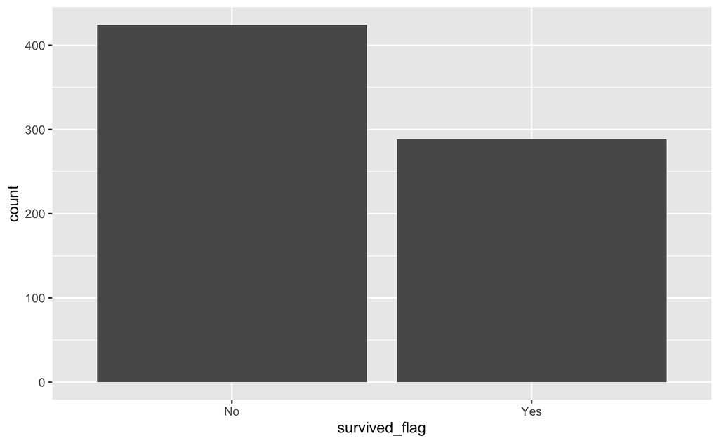

```r
titanic_clean %>%
  ggplot(aes(x = survived_flag)) +
  geom_bar()
```

This is a pretty good plot to start out with, the ratio of surviving vs not.

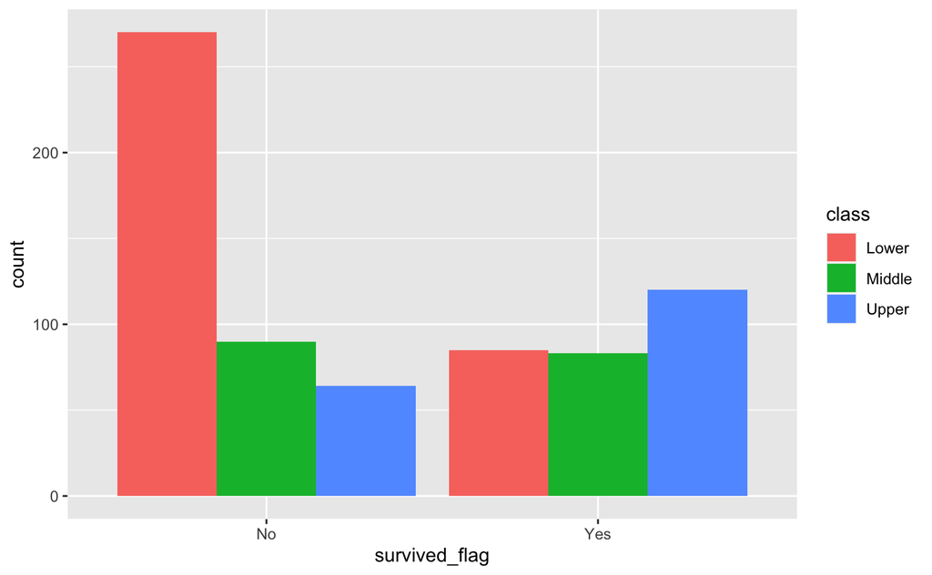

```r
titanic_clean %>%
  ggplot(aes(x = survived_flag, fill = class)) +
  geom_bar(position = "dodge")
```

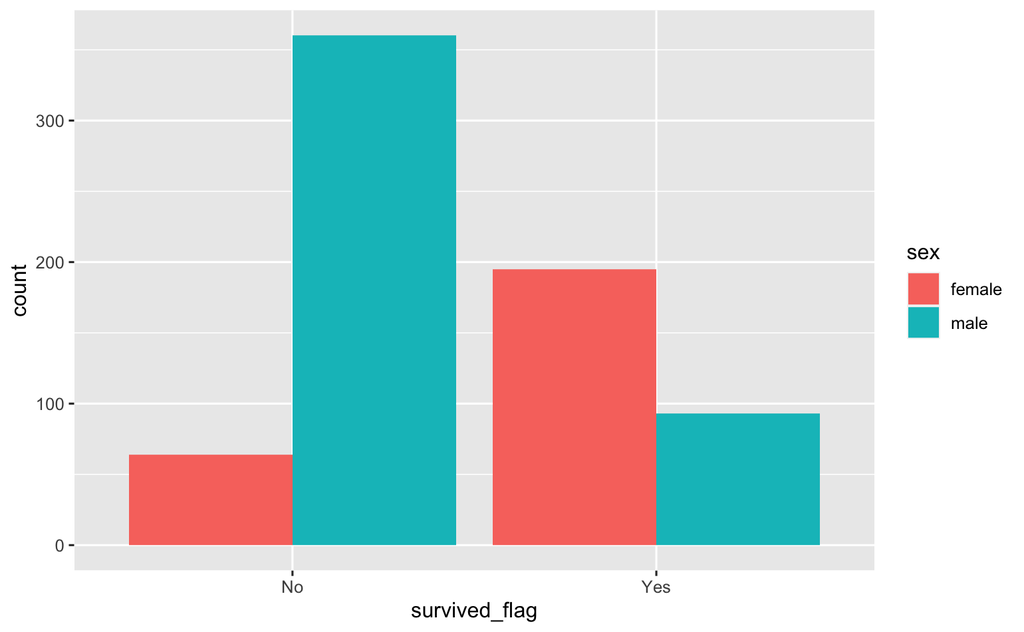

```r
titanic_clean %>%
  ggplot(aes(x = survived_flag, fill = sex)) +
  geom_bar(position = "dodge")
```

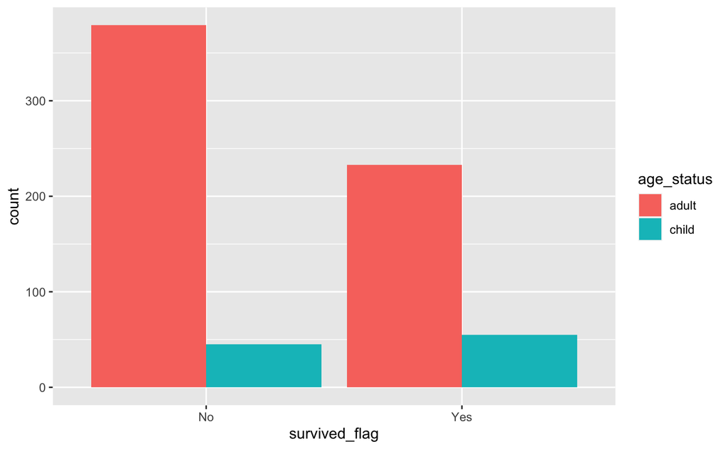

```r
titanic_clean %>%
  ggplot(aes(x = survived_flag, fill = age_status)) +
  geom_bar(position = "dodge")
```

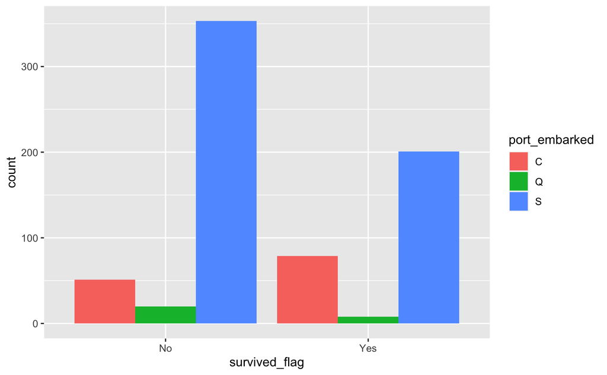

```r
titanic_clean %>%
  ggplot(aes(x = survived_flag, fill = port_embarked)) +
  geom_bar(position = "dodge")
```

Equally, the variables which show the probabilities of dying are: - Having a ticket for the lower class - Being male - Being an adult - Interestingly, also embarking in Southampton

# 1.3 Question 3

Now you can start to build your model. Create your testing and training set using an appropriate split. Check you have balanced sets. Write down why you chose the split you did and produce output tables to show whether or not it is balanced. [Extra - if you want to force balanced testing and training sets, have a look at the stratified() function in package splitstackshape (you can specify multiple variables to stratify on by passing a vector of variable names to the group argument, and get back testing and training sets with argument bothSets = TRUE)]

```r
set.seed(15)

n_data <- nrow(titanic_clean)
test_index <- sample(1:n_data, size = n_data*0.2)
titanic_test <- slice(titanic_clean, test_index)
titanic_train <- slice(titanic_clean, -test_index)
```

```r
titanic_test %>%
  janitor::tabyl(survived_flag)
```

```
 survived_flag  n   percent
            No 88 0.6197183
           Yes 54 0.3802817
```

```r
titanic_train %>%
  janitor::tabyl(survived_flag)
```

```
 survived_flag   n   percent
            No 336 0.5894737
           Yes 234 0.4105263
```

I started at a seed of 15 (because I had to start somewhere). This created a test/train split which was pretty well balanced, the proportions are pretty much the same.

# 1.4 Question 4

Create your decision tree to try and predict survival probability using an appropriate method, and create a decision tree plot.

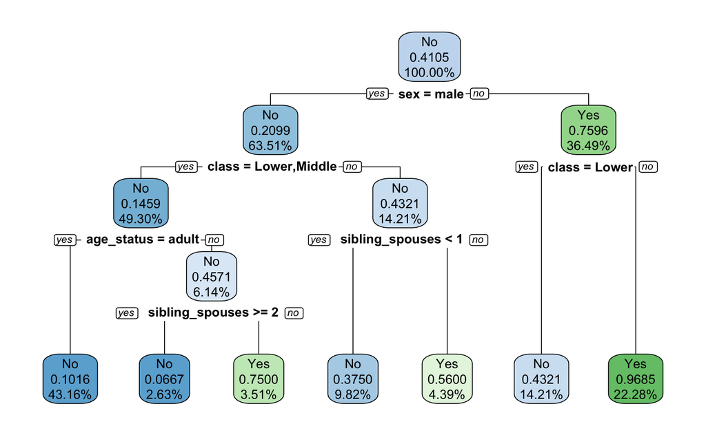

```r
titanic_tree <- rpart(
  formula = survived_flag ~ .,
  data = titanic_train,
  method = 'class'
)

rpart.plot(titanic_tree,
           yesno = 2,
           fallen.leaves = TRUE,
           faclen = 6,
           digits = 4)
```

no = dying yes = surviving

# 1.5 Question 5

Write down what this tells you, in detail. What variables are important? What does each node tell you? Who has the highest chance of surviving? Who has the lowest? Provide as much detail as you can.

The important variables are sex, class, age_status, and sibling_spouses.

# 1.6 Question 6

[output not shown]

```r
titanic_test_pred %>%
  specificity(truth = survived_flag, estimate = pred)

titanic_test_pred %>%
  sensitivity(truth = survived_flag, estimate = pred)
```

[output not shown]

| .metric | .estimator | .estimate |
| --- | --- | --- |
| sensitivity | binary | 0.8068182 |

Sensitivity and specificity depend on the question that you’re setting, i.e. we are trying to predict the probability of someone not dying.